# Practical 4 - A space-time model with `inlabru`

Spatial and Spatio-Temporal Bayesian Models with `R-INLA`

## 1. Introduction

In this tutorial we use a dataset that comprises daily maximum 8-hour average ground level ozone (O3, ppb) concentrations for the period July 1 and August 31 in 2006, measured at 28 monitoring sites in the state of New York, USA. The stations are part of the Environmental Protection Agency (EPA) monitoring network. Ozone occurs naturally in the upper atmosphere and protects the Earth from the sun’s rays. However, at ground level it can be harmful for population health, as it can lead to adverse respiratory effects. Ozone is most likely to reach worrisome levels on hot sunny days in urban environments (even so it can still reach high levels during colder months).  
Ozone is one of the “criteria pollutants” regularly monitored by the US EPA.

The dataset used for this tutorial is included in the packages `spBayes` and `spTimer`. Today we will use the package `spTimer` by Bakar and Sahu (2015) to model ozone concentrations in New York state. The paper by Bakar and Sahu (2015) uses this dataset for demonstration. Here we follow their analysis.

The data available are as follows:

- `s.index`: index of the monitoring station in the NY state
- `Longitude` and `Latitude`: spatial coordinates of the monitoring stations
- `Year`, `Month` and `Day`: temporal coordinates of the measurement
- `o8hrmax`: daily 8-hour maximum average ozone concentrations (parts per billion)
- `cMAXTMP`: maximum temperature (in degree Celsius)
- `WDSP`: wind speed (knots),
- `RH`: percentage average relative humidity

We use `o8hrmax` concentrations as outcome and `cMAXTMP`, `WDSP`, and `RH` as predictors.

## 2. The New York dataset: explore the data

The data are obtained from 28 monitoring sites, between July 1 and August 31 in 2006.

- Load the data in `R`

```r
library(tidyverse)
library(spTimer)
data(NYdata)
dim(NYdata)
```

```
## [1] 1736   10
```

- Now, we print the data, formatting these in a table.

```r
head(NYdata)
```

```
##   s.index Longitude Latitude Year Month Day o8hrmax  cMAXTMP     WDSP       RH
## 1       1   -73.757   42.681 2006     7   1   53.88 27.85772 5.459953 2.766221
## 2       1   -73.757   42.681 2006     7   2   57.13 30.11563 8.211767 3.197750
## 3       1   -73.757   42.681 2006     7   3   72.00 30.00001 4.459581 3.225186
## 4       1   -73.757   42.681 2006     7   4   36.63 27.89656 3.692225 4.362334
## 5       1   -73.757   42.681 2006     7   5   42.63 25.65698 4.374314 3.950320
## 6       1   -73.757   42.681 2006     7   6   30.88 24.61968 4.178086 3.420533
```

```r
library(mapview)
stations <- cbind(unique(NYdata[,1]), unique(NYdata[,2:3]))

# set the map projection to a common projection standard such as WGS84 via the argument crs = 4326
mapview(stations, xcol = "Longitude", ycol = "Latitude", crs = 4269, grid = FALSE)
```

[interactive chart not shown]

- We create a variable `date` using the package `lubridate`, which is part of the core `tidyverse`.

```r
library(lubridate)
NYdata <- NYdata %>%
  mutate(date = make_date(Year, Month, Day))
glimpse(NYdata)
```

```
## Rows: 1,736
## Columns: 11
## $ s.index   <int> 1, 1, 1, 1, 1, 1, 1, 1, 1, 1, 1, 1, 1, 1, 1, 1, 1, 1, 1, 1, …
## $ Longitude <dbl> -73.757, -73.757, -73.757, -73.757, -73.757, -73.757, -73.75…
## $ Latitude  <dbl> 42.681, 42.681, 42.681, 42.681, 42.681, 42.681, 42.681, 42.6…
## $ Year      <int> 2006, 2006, 2006, 2006, 2006, 2006, 2006, 2006, 2006, 2006, …
## $ Month     <int> 7, 7, 7, 7, 7, 7, 7, 7, 7, 7, 7, 7, 7, 7, 7, 7, 7, 7, 7, 7, …
## $ Day       <int> 1, 2, 3, 4, 5, 6, 7, 8, 9, 10, 11, 12, 13, 14, 15, 16, 17, 1…
## $ o8hrmax   <dbl> 53.88, 57.13, 72.00, 36.63, 42.63, 30.88, 38.25, 42.12, 46.5…
## $ cMAXTMP   <dbl> 27.85772, 30.11563, 30.00001, 27.89656, 25.65698, 24.61968, …
## $ WDSP      <dbl> 5.459953, 8.211767, 4.459581, 3.692225, 4.374314, 4.178086, …
## $ RH        <dbl> 2.766221, 3.197750, 3.225186, 4.362334, 3.950320, 3.420533, …
## $ date      <date> 2006-07-01, 2006-07-02, 2006-07-03, 2006-07-04, 2006-07-05,…
```

- We now plot the concentrations of ozone for each monitoring station using the package `mvtsplot`, which allows the visualization of Multivariate time Series (Link: http://www.biostat.jhsph.edu/~rpeng/RR/mvtsplot/). To be able to use it, we need to convert the data from long to wide format.

```r
# select ozone data
O3 <- NYdata %>% select(s.index, o8hrmax, date)
dim(O3) #1736    3
```

```
## [1] 1736    3
```

```r
O3_wide = O3 %>% spread(s.index, o8hrmax)
dim(O3_wide) #62 29
```

```
## [1] 62 29
```

```r
O3_wide <- O3_wide[,-1] # remove date
O3_wide <- data.matrix(O3_wide)
dim(O3_wide)
```

```
## [1] 62 28
```

```r
colnames(O3_wide) <- unique(O3[,1])
```

And now plot the ozone concentrations for the 28 monitoring stations

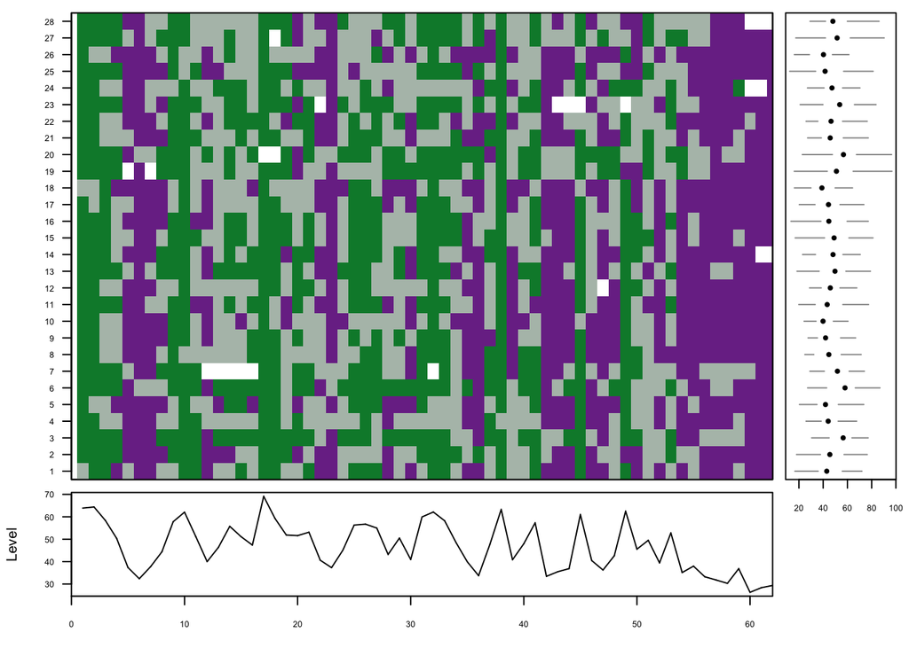

Daily ozone levels for 28 monitoring stations, Jul 1– Aug 31, 2006

```r
library(mvtsplot)
# Daily ozone levels for 28 monitoring stations, Jul 1– Aug 31, 2006.
mvtsplot(O3_wide, group = NULL, xtime = NULL, norm = c("global"),
         levels = 3, smooth.df = NULL, margin = TRUE, sort =NULL,
         main = "", palette = "PRGn", rowstat = "median", xlim,
         bottom.ylim = NULL, right.xlim=NULL, gcol = 3)
```

In the plot we use as color `PRGn` (default) from the `RColorBrewer` palettes. Here green indicates high values and purple indicates low values. Missing data are denoted by the color white. The bottom panel shows the overall median. Finally, on the right hand side panel, we can see the boxplots of the data in each time series.

- Moreover, we can check the basic statistics for ozone concentrations and make the histogram

```r
summary(NYdata$o8hrmax)
```

```
##    Min. 1st Qu.  Median    Mean 3rd Qu.    Max.    NA's
##   12.38   37.35   46.50   47.82   57.63  107.00      24
```

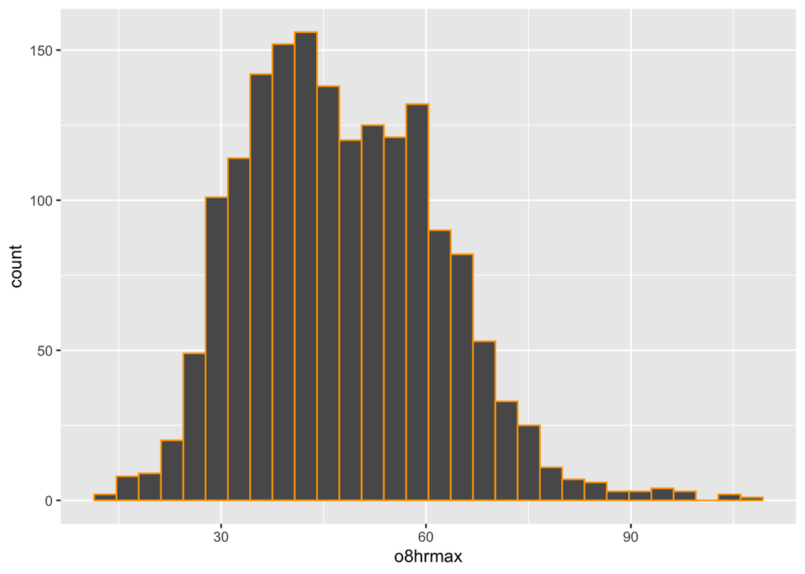

Histgram of ozone concentrations

```r
NYdata %>%
  ggplot()+
  geom_histogram(aes(o8hrmax), col="orange")
```

- We can visualize the relationships between the data using `GGally`:

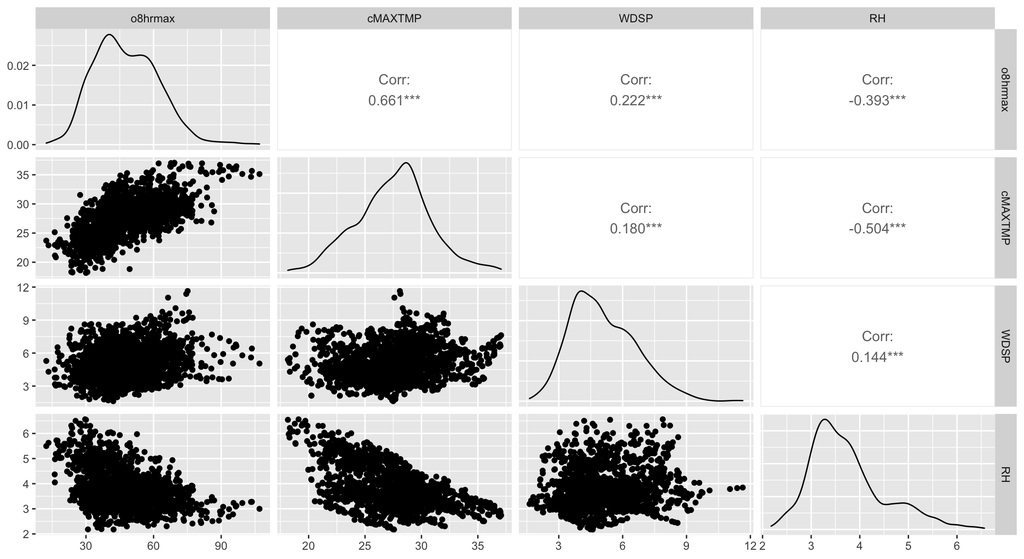

Figure 4. Plot of the correlation between variables in analysis

```r
library(GGally)
ggpairs(NYdata[,7:10]) # print correlations between variables
```

- We print the table of the correlations between ozone and the three predictors using the package `corrr`:

```r
library(corrr)
tab_cor = NYdata %>%
  select(o8hrmax, cMAXTMP, WDSP, RH) %>%
  correlate() %>%
  shave(upper = TRUE) %>%
  fashion(decimals = 2, na_print = "—")

tab_cor
```

```
##      term o8hrmax cMAXTMP WDSP RH
## 1 o8hrmax       —       —    —  —
## 2 cMAXTMP     .66       —    —  —
## 3    WDSP     .22     .18    —  —
## 4      RH    -.39    -.50  .14  —
```

- We create a variable which is an index for time:

```r
NYdata$time = rep(1:n_distinct(NYdata$date),
                   n_distinct(NYdata$s.index))
```

and we consider, for reducing the computational costs, only the first 30 time points:

```r
NYdata = NYdata %>%
  filter(time <= 30)
```

Compute the square root transformation of the response variable

```r
NYdata$sqrto8hrmax = sqrt(NYdata$o8hrmax)
```

```r
# define prediction sites for cross-validation (i.e. validation sites)
s <- c(8,11,12,14,18,21,24,28) # 8 stations

# Training data
DataFit = NYdata %>%
  filter(!(s.index %in% s))
dim(DataFit)
```

```
## [1] 600  13
```

```r
# Dim = 600 (20stations*30days) * 12

# Validation data
# select data for prediction (validation set)
DataValPred =  NYdata %>%
  filter(s.index %in% s)
dim(DataValPred)
```

```
## [1] 240  13
```

```r
# dim = 240 (8stations*30days) * 12
```

## 3. Geostatistical spatio-temporal model

- $\boldsymbol{Y}_t =(Y(\mathbf{s}_1,t), \dots, Y(\mathbf{s}_n,t))'$ be the observed data at location $\mathbf{s}$ in day $t$
- $\boldsymbol{O}_t =(O(\mathbf{s}_1,t), \dots, O(\mathbf{s}_n,t))'$ be the true value corresponding to $\boldsymbol{Y}_t$.

$$\begin{equation*}
\begin{split}
%Y(\mathbf{s}_i,t) &= \boldsymbol{X}'(\mathbf{s}_i,t)
\boldsymbol{\beta} +
\boldsymbol{\eta}(\mathbf{s}_i,t)+\boldsymbol{\epsilon}(\mathbf{s}_i,t)
\boldsymbol{Y}_t &= \boldsymbol{O}_t +\boldsymbol{\epsilon}_t\\
\boldsymbol{O}_t &= \boldsymbol{X}_t \boldsymbol{\beta} +
\boldsymbol{\eta}_t
\end{split}
\end{equation*}$$

where:

- $\boldsymbol{X}_t$ are the covariate values and $\boldsymbol{\beta}$ are the regression coefficients
- $\boldsymbol{\eta}_t=(\eta(\mathbf{s}_1,t), \dots, \eta(\mathbf{s}_n,t))'$ are the spatio-temporal random effects, assumed to follow $N(\mathbf{0}, \Sigma_{\eta})$ independently in time, where $\Sigma_{\eta}=\sigma_{\eta}^{2} S_{\eta}$, here $\sigma_{\eta}^2$ is the site invariant spatial variance and $S_{\eta}$ is the spatial correlation matrix.
- $\boldsymbol{\epsilon}_t=(\epsilon(\mathbf{s}_1,t), \dots, \epsilon(\mathbf{s}_n,t))'$ is the nugget effect or the pure error term, independent in space and time.

## 4. Create the mesh and the SPDE model

- We consider a rough mesh:

```r
library(INLA)
bnd <- inla.nonconvex.hull(cbind(DataFit$Longitude, DataFit$Latitude),
                            convex = 1)

mesh = inla.mesh.2d(loc = cbind(DataFit$Longitude, DataFit$Latitude),
                    #max.edge = c(0.5, 4))
                    max.n.strict = c(100, 20))
```

Explain the option `max.n`.

```r
library(inlabru)
ggplot() +
  gg(mesh) +
  geom_point(data = DataFit, aes(Longitude, Latitude))
```

[output not shown]

```r
spde = inla.spde2.pcmatern(mesh = mesh,
                           prior.range = c(0.1, 0.9),
                           prior.sigma = c(1, 0.01))
spde$n.spde #n. of mesh vertices
```

```
## [1] 90
```

```r
coordinates(DataFit) = c("Longitude","Latitude")
class(DataFit)
```

```
## [1] "SpatialPointsDataFrame"
## attr(,"package")
## [1] "sp"
```

```r
cmp  = ~ Intercept(1) +   cMAXTMP + WDSP + RH +
  SPDE(coordinates, model = spde,
       group = time, control.group = list(model = "ar1"))
```

We then define the **likelihood**

```r
library(inlabru)
lik = like(formula = sqrto8hrmax ~ Intercept  + cMAXTMP + WDSP + RH + SPDE,
           family = "gaussian",
           data = DataFit)
```

```r
#p(sigma > sigma0)=alpha
pc.prec = list(prec = list(prior = "pc.prec", param = c(70, 0.01)))

fit = bru(cmp, lik,
          options =  list(control.family = list(hyper = pc.prec)))
summary(fit)
```

```
## inlabru version: 2.5.2
## INLA version: 22.06.11
## Components:
##   Intercept: Model types main='linear', group='exchangeable', replicate='iid'
##   cMAXTMP: Model types main='linear', group='exchangeable', replicate='iid'
##   WDSP: Model types main='linear', group='exchangeable', replicate='iid'
##   RH: Model types main='linear', group='exchangeable', replicate='iid'
##   SPDE: Model types main='spde', group='ar1', replicate='iid'
## Likelihoods:
##   Family: 'gaussian'
##     Data class: 'SpatialPointsDataFrame'
##     Predictor: sqrto8hrmax ~ Intercept + cMAXTMP + WDSP + RH + SPDE
## Time used:
##     Pre = 8.34, Running = 16.8, Post = 3.5, Total = 28.6
## Fixed effects:
##             mean    sd 0.025quant 0.5quant 0.975quant   mode kld
## Intercept  1.493 1.295     -1.066    1.498      4.024  1.509   0
## cMAXTMP    0.209 0.036      0.138    0.209      0.280  0.208   0
## WDSP       0.046 0.033     -0.019    0.046      0.109  0.046   0
## RH        -0.109 0.108     -0.319   -0.110      0.106 -0.111   0
##
## Random effects:
##   Name     Model
##     SPDE SPDE2 model
##
## Model hyperparameters:
##                                           mean    sd 0.025quant 0.5quant
## Precision for the Gaussian observations 14.378 2.256     10.371   14.219
## Range for SPDE                           2.822 0.373      2.160    2.795
## Stdev for SPDE                           0.740 0.048      0.651    0.739
## GroupRho for SPDE                        0.693 0.051      0.583    0.696
##                                         0.975quant   mode
## Precision for the Gaussian observations     19.323 13.934
## Range for SPDE                               3.644  2.737
## Stdev for SPDE                               0.841  0.734
## GroupRho for SPDE                            0.785  0.701
##
## Deviance Information Criterion (DIC) ...............: 435.67
## Deviance Information Criterion (DIC, saturated) ....: 8845.56
## Effective number of parameters .....................: 341.99
##
## Watanabe-Akaike information criterion (WAIC) ...: 399.94
## Effective number of parameters .................: 233.45
##
## Marginal log-Likelihood:  -488.17
##  is computed
## Posterior summaries for the linear predictor and the fitted values are computed
## (Posterior marginals needs also 'control.compute=list(return.marginals.predictor=TRUE)')
```

```r
names(fit$marginals.fixed)
```

```
## [1] "Intercept" "cMAXTMP"   "WDSP"      "RH"
```

```r
names(fit$marginals.random)
```

```
## [1] "SPDE"
```

```r
fit$summary.fixed[,c("mean","0.025quant","0.975quant")]
```

```
##                  mean 0.025quant 0.975quant
## Intercept  1.49318138 -1.0657413  4.0239803
## cMAXTMP    0.20888216  0.1380272  0.2804311
## WDSP       0.04567626 -0.0194703  0.1094439
## RH        -0.10891737 -0.3194125  0.1059307
```

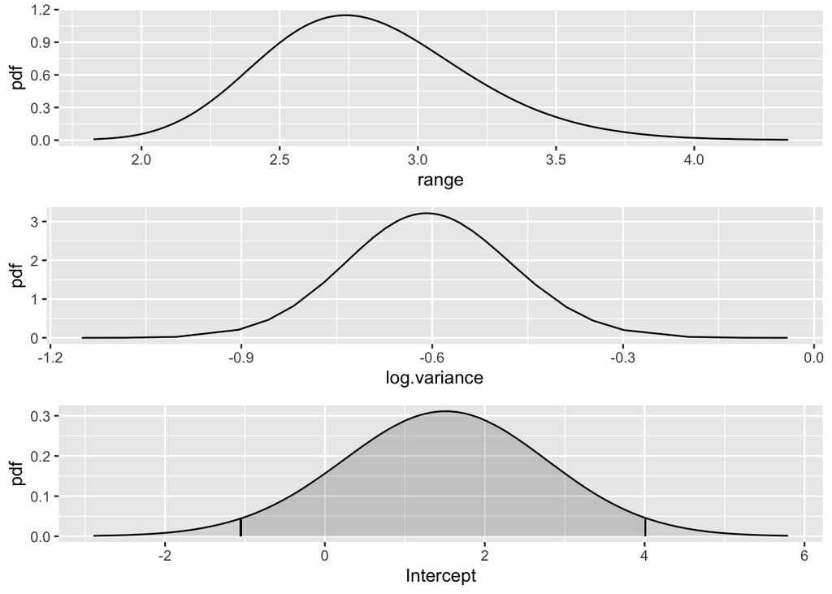

```r
int.plot <- plot(fit, "Intercept")
spde.range <- spde.posterior(fit, "SPDE", what = "range")
spde.logvar <- spde.posterior(fit, "SPDE", what = "log.variance")
range.plot <- plot(spde.range)
var.plot <- plot(spde.logvar)

multiplot(range.plot, var.plot, int.plot)
```

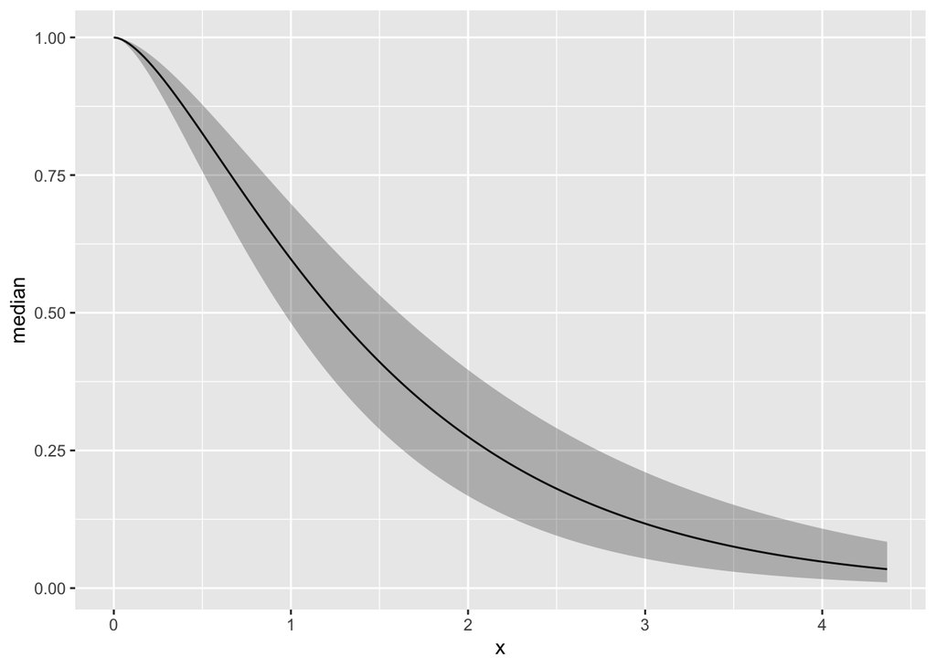

```r
plot(spde.posterior(fit, "SPDE", what = "matern.correlation"))
```

## 5. Prediction at the hold-out sites

```r
coordinates(DataValPred) = c("Longitude","Latitude")
class(DataValPred)
```

```
## [1] "SpatialPointsDataFrame"
## attr(,"package")
## [1] "sp"
```

```r
ValPred = predict(fit, DataValPred,
                ~ Intercept + SPDE + cMAXTMP + WDSP + RH)
```

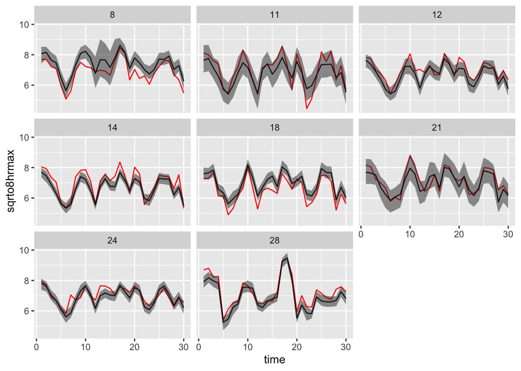

```r
as.data.frame(ValPred) %>%
  ggplot() +
  geom_line(aes(time, sqrto8hrmax, group = s.index), color = "red") +
  geom_line(aes(time, median, group = s.index)) +
  geom_ribbon(aes(time, ymin = q0.025, ymax = q0.975, group = s.index), alpha = 0.5) +
  facet_wrap(.~s.index)
```

## 6. Prediction at the grid level

```r
data(NYgrid)
dim(NYgrid)
```

```
## [1] 6200    9
```

```r
class(NYgrid)
```

```
## [1] "data.frame"
```

```r
head(NYgrid)
```

```
##   s.index Year Month Day  cMAXTMP     WDSP       RH Longitude Latitude
## 1       1 2006     7   1 25.78623 5.602757 3.311548       -72     45.2
## 2       1 2006     7   2 29.35546 7.946272 3.260382       -72     45.2
## 3       1 2006     7   3 28.04157 3.891001 2.804062       -72     45.2
## 4       1 2006     7   4 26.55014 3.324329 4.459596       -72     45.2
## 5       1 2006     7   5 24.65790 5.221672 4.096214       -72     45.2
## 6       1 2006     7   6 23.54229 3.235730 3.737357       -72     45.2
```

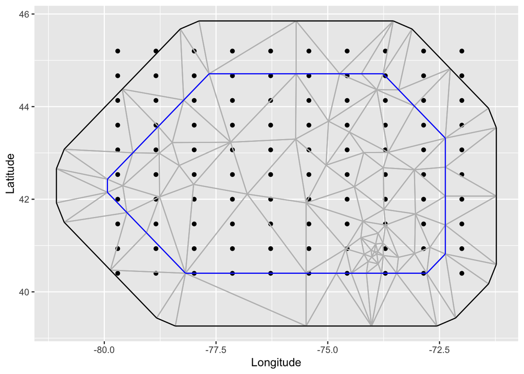

```r
NYgrid %>%
  distinct(Longitude,Latitude) %>%
  ggplot()+
  geom_point(aes(Longitude,Latitude)) +
  gg(mesh)
```

- We create a variable which is an index for time:

```r
NYgrid <- NYgrid %>%
  mutate(date = make_date(Year, Month, Day))
glimpse(NYgrid)
```

```
## Rows: 6,200
## Columns: 10
## $ s.index   <int> 1, 1, 1, 1, 1, 1, 1, 1, 1, 1, 1, 1, 1, 1, 1, 1, 1, 1, 1, 1, …
## $ Year      <int> 2006, 2006, 2006, 2006, 2006, 2006, 2006, 2006, 2006, 2006, …
## $ Month     <int> 7, 7, 7, 7, 7, 7, 7, 7, 7, 7, 7, 7, 7, 7, 7, 7, 7, 7, 7, 7, …
## $ Day       <int> 1, 2, 3, 4, 5, 6, 7, 8, 9, 10, 11, 12, 13, 14, 15, 16, 17, 1…
## $ cMAXTMP   <dbl> 25.78623, 29.35546, 28.04157, 26.55014, 24.65790, 23.54229, …
## $ WDSP      <dbl> 5.6027574, 7.9462719, 3.8910009, 3.3243287, 5.2216721, 3.235…
## $ RH        <dbl> 3.311548, 3.260382, 2.804062, 4.459596, 4.096214, 3.737357, …
## $ Longitude <dbl> -72, -72, -72, -72, -72, -72, -72, -72, -72, -72, -72, -72, …
## $ Latitude  <dbl> 45.2, 45.2, 45.2, 45.2, 45.2, 45.2, 45.2, 45.2, 45.2, 45.2, …
## $ date      <date> 2006-07-01, 2006-07-02, 2006-07-03, 2006-07-04, 2006-07-05,…
```

```r
NYgrid$time = rep(1:n_distinct(NYgrid$date),
                   n_distinct(NYgrid$s.index))
```

```r
NYgrid = NYgrid %>% filter(time <= 6)
```

```r
coordinates(NYgrid) = c("Longitude","Latitude")
class(NYgrid)
```

```
## [1] "SpatialPointsDataFrame"
## attr(,"package")
## [1] "sp"
```

- Transform the grid into a `SpatialPixelsDataFrame`:

```r
grid = sp::SpatialPixelsDataFrame(NYgrid@coords,
                                  data = NYgrid@data)
class(grid)
```

```
## [1] "SpatialPixelsDataFrame"
## attr(,"package")
## [1] "sp"
```

```r
dim(grid@data)
```

```
## [1] 600   9
```

```r
glimpse(grid@data)
```

```
## Rows: 600
## Columns: 9
## $ s.index <int> 1, 1, 1, 1, 1, 1, 2, 2, 2, 2, 2, 2, 3, 3, 3, 3, 3, 3, 4, 4, 4,…
## $ Year    <int> 2006, 2006, 2006, 2006, 2006, 2006, 2006, 2006, 2006, 2006, 20…
## $ Month   <int> 7, 7, 7, 7, 7, 7, 8, 8, 8, 8, 8, 8, 7, 7, 7, 7, 7, 7, 8, 8, 8,…
## $ Day     <int> 1, 2, 3, 4, 5, 6, 1, 2, 3, 4, 5, 6, 1, 2, 3, 4, 5, 6, 1, 2, 3,…
## $ cMAXTMP <dbl> 25.78623, 29.35546, 28.04157, 26.55014, 24.65790, 23.54229, 26…
## $ WDSP    <dbl> 5.602757, 7.946272, 3.891001, 3.324329, 5.221672, 3.235730, 5.…
## $ RH      <dbl> 3.311548, 3.260382, 2.804062, 4.459596, 4.096214, 3.737357, 3.…
## $ date    <date> 2006-07-01, 2006-07-02, 2006-07-03, 2006-07-04, 2006-07-05, 2…
## $ time    <int> 1, 2, 3, 4, 5, 6, 1, 2, 3, 4, 5, 6, 1, 2, 3, 4, 5, 6, 1, 2, 3,…
```

- Prova MASKING

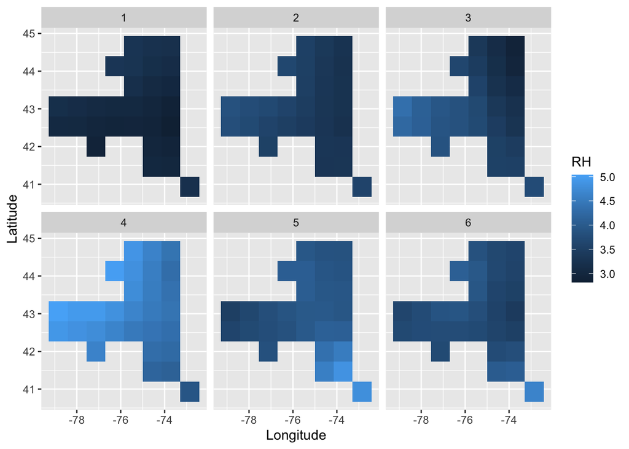

```r
library(maps)
eus <- (map.where(database="state", x=NYgrid@coords[,1], y=NYgrid@coords[,2]))
dummy <- rep(0, length(NYgrid@coords[,1]))
eastUS <- NULL
eastUS <- data.frame(lon=NYgrid@coords[,1],lat=NYgrid@coords[,2],state=eus,dummy=dummy)
eastUS[!is.na(eastUS[,3]),4]<-1
eastUS[eastUS[,3]=="pennsylvania" & !is.na(eastUS[,3]),4]<-0
eastUS[eastUS[,3]=="new jersey" & !is.na(eastUS[,3]),4]<-0
eastUS[eastUS[,3]=="connecticut" & !is.na(eastUS[,3]),4]<-0
eastUS[eastUS[,3]=="massachusetts:main" & !is.na(eastUS[,3]),4]<-0
eastUS[eastUS[,3]=="new hampshire" & !is.na(eastUS[,3]),4]<-0
eastUS[eastUS[,3]=="vermont" & !is.na(eastUS[,3]),4]<-0
maskindex <- eastUS[, 4]
prova <- grid[!!maskindex,]

ggplot()+
  gg(prova, aes(fill=RH))+
  facet_wrap(~time)
```

- COMPUTE PREDICTIONS

```r
GridPred = predict(fit, grid,
                ~ (Intercept + SPDE + cMAXTMP + WDSP + RH)^2)
head(GridPred)
```

```
##   s.index Year Month Day  cMAXTMP     WDSP       RH       date time     mean
## 1       1 2006     7   1 25.78623 5.602757 3.311548 2006-07-01    1 45.76094
## 2       1 2006     7   2 29.35546 7.946272 3.260382 2006-07-02    2 58.10679
## 3       1 2006     7   3 28.04157 3.891001 2.804062 2006-07-03    3 51.97595
## 4       1 2006     7   4 26.55014 3.324329 4.459596 2006-07-04    4 44.71175
## 5       1 2006     7   5 24.65790 5.221672 4.096214 2006-07-05    5 41.26893
## 6       1 2006     7   6 23.54229 3.235730 3.737357 2006-07-06    6 37.69728
##         sd   q0.025   median   q0.975     smin     smax         cv       var
## 1 2.891016 40.48617 45.58357 52.09791 39.35886 53.18657 0.06317651  8.357976
## 2 3.337530 51.53568 57.99847 64.69671 49.38943 66.06019 0.05743787 11.139108
## 3 3.127074 47.31264 51.40668 58.46552 44.05111 59.92270 0.06016388  9.778594
## 4 2.884131 39.32263 44.73598 49.97871 36.06087 51.85419 0.06450498  8.318209
## 5 2.747805 35.93419 41.26513 46.60732 34.90966 48.96161 0.06658289  7.550431
## 6 2.945660 32.76722 37.46630 43.68473 31.06645 45.83921 0.07813985  8.676911
```

AND MAPS

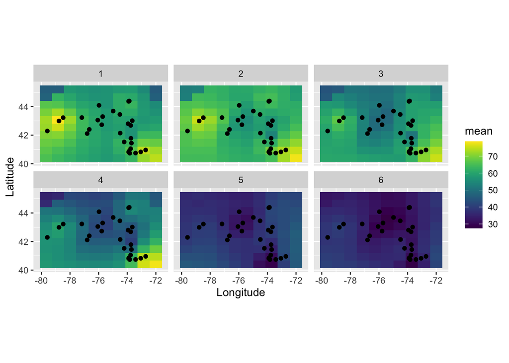

```r
library(viridis)
ggplot() +
  gg(GridPred, aes(Longitude, Latitude, fill = mean))  +
  facet_wrap(.~time) +
  scale_fill_viridis() +
  coord_equal()+
  geom_point(data = stations, aes(Longitude, Latitude))
```

Bakar, Khandoker Shuvo, and Sujit K. Sahu. 2015. “spTimer: Spatio-Temporal Bayesian Modeling Using R.” *Journal of Statistical Software* 63 (15): 1–32. http://www.jstatsoft.org/v63/i15.